# SAIS

# P1 : Insulting people via internet is a type of information crimes.

```python
SAIS.P1.value_counts()
```

```
Aware & Follow      128
Aware & Unfollow      8
Unaware               7
Name: P1, dtype: int64
```

```python
SAIS.groupby(['Job_Status']).P1.value_counts()
```

```
Job_Status  P1
Employee    Aware & Follow      57
            Aware & Unfollow     2
            Unaware              2
Other       Aware & Follow      49
            Unaware              2
Student     Aware & Follow      22
            Aware & Unfollow     6
            Unaware              3
Name: P1, dtype: int64
```

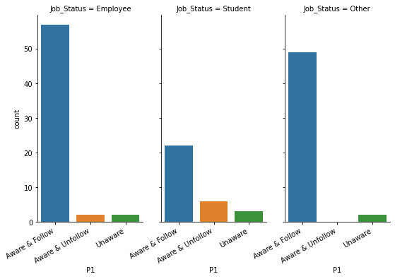

```python
chart=sns.catplot(x='P1', col='Job_Status', kind='count', data=SAIS, height=5, aspect=0.5,
                   order=SAIS['P1'].value_counts().index)
chart.set_xticklabels(rotation=30, horizontalalignment='right')
```

```python
SAIS.groupby(['Age']).P1.value_counts()
```

```
Age      P1
18 - 25  Aware & Follow      23
         Aware & Unfollow     5
         Unaware              4
26 - 35  Aware & Follow      40
         Aware & Unfollow     3
36 - 45  Aware & Follow      23
46 - 60  Aware & Follow      42
         Unaware              3
Name: P1, dtype: int64
```

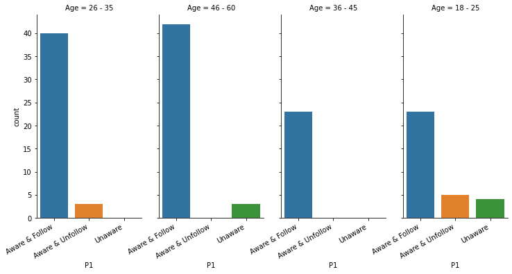

```python
chart=sns.catplot(x='P1', col='Age', kind='count', data=SAIS, height=5, aspect=0.5,
                   order=SAIS['P1'].value_counts().index)
chart.set_xticklabels(rotation=30, horizontalalignment='right')
```

```python
SAIS.groupby(['Gender']).P1.value_counts()
```

```
Gender  P1
Female  Aware & Follow      69
        Aware & Unfollow     2
        Unaware              2
Male    Aware & Follow      59
        Aware & Unfollow     6
        Unaware              5
Name: P1, dtype: int64
```

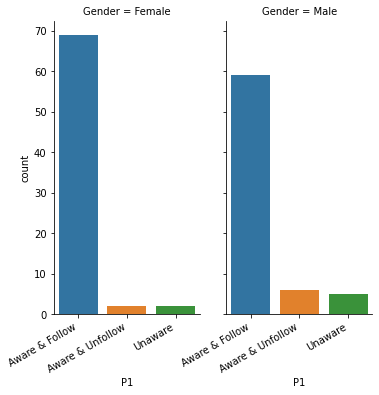

```python
chart=sns.catplot(x='P1', col='Gender', kind='count', data=SAIS, height=5, aspect=0.5,
                   order=SAIS['P1'].value_counts().index)
chart.set_xticklabels(rotation=30, horizontalalignment='right')
```

# P2 : Snooping, viewing, and intercepting data via network are information crimes.

```python
SAIS.P2.value_counts()
```

```
Aware & Follow      127
Unaware               8
Aware & Unfollow      8
Name: P2, dtype: int64
```

```python
SAIS.groupby(['Job_Status']).P2.value_counts()
```

```
Job_Status  P2
Employee    Aware & Follow      54
            Unaware              5
            Aware & Unfollow     2
Other       Aware & Follow      49
            Aware & Unfollow     1
            Unaware              1
Student     Aware & Follow      24
            Aware & Unfollow     5
            Unaware              2
Name: P2, dtype: int64
```

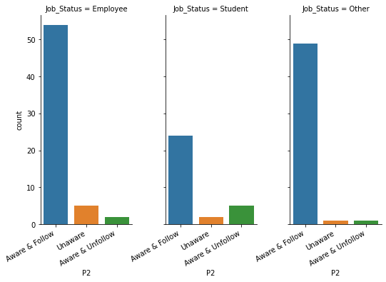

```python
chart=sns.catplot(x='P2', col='Job_Status', kind='count', data=SAIS, height=5, aspect=0.5,
                   order=SAIS['P2'].value_counts().index)
chart.set_xticklabels(rotation=30, horizontalalignment='right')
```

```python
SAIS.groupby(['Age']).P2.value_counts()
```

```
Age      P2
18 - 25  Aware & Follow      26
         Aware & Unfollow     4
         Unaware              2
26 - 35  Aware & Follow      37
         Unaware              4
         Aware & Unfollow     2
36 - 45  Aware & Follow      23
46 - 60  Aware & Follow      41
         Aware & Unfollow     2
         Unaware              2
Name: P2, dtype: int64
```

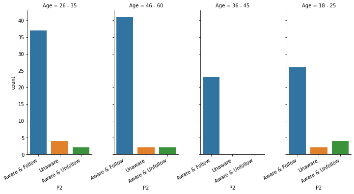

```python
chart=sns.catplot(x='P2', col='Age', kind='count', data=SAIS, height=5, aspect=0.5,
                   order=SAIS['P2'].value_counts().index)
chart.set_xticklabels(rotation=30, horizontalalignment='right')
```

```python
SAIS.groupby(['Gender']).P2.value_counts()
```

```
Gender  P2
Female  Aware & Follow      68
        Unaware              4
        Aware & Unfollow     1
Male    Aware & Follow      59
        Aware & Unfollow     7
        Unaware              4
Name: P2, dtype: int64
```

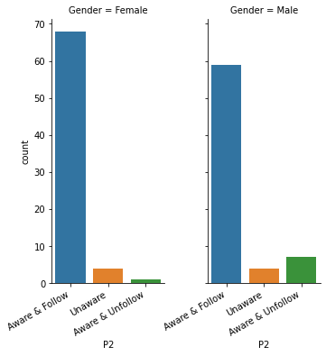

```python
chart=sns.catplot(x='P2', col='Gender', kind='count', data=SAIS, height=5, aspect=0.5,
                   order=SAIS['P2'].value_counts().index)
chart.set_xticklabels(rotation=30, horizontalalignment='right')
```

# P3 : Data can not be used without owner permission.

```python
SAIS.groupby(['Job_Status']).P3.value_counts()
```

```
Job_Status  P3
Employee    Aware & Follow      55
            Aware & Unfollow     3
            Unaware              3
Other       Aware & Follow      41
            Unaware              6
            Aware & Unfollow     4
Student     Aware & Follow      21
            Aware & Unfollow     8
            Unaware              2
Name: P3, dtype: int64
```

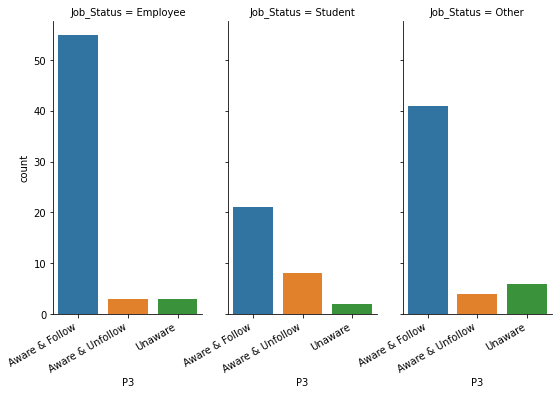

```python
chart=sns.catplot(x='P3', col='Job_Status', kind='count', data=SAIS, height=5, aspect=0.5,
                   order=SAIS['P3'].value_counts().index)
chart.set_xticklabels(rotation=30, horizontalalignment='right')
```

```python
SAIS.groupby(['Age']).P3.value_counts()
```

```
Age      P3
18 - 25  Aware & Follow      22
         Aware & Unfollow     8
         Unaware              2
26 - 35  Aware & Follow      32
         Unaware              7
         Aware & Unfollow     4
36 - 45  Aware & Follow      22
         Unaware              1
46 - 60  Aware & Follow      41
         Aware & Unfollow     3
         Unaware              1
Name: P3, dtype: int64
```

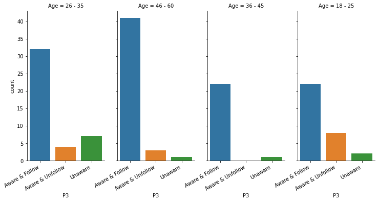

```python
chart=sns.catplot(x='P3', col='Age', kind='count', data=SAIS, height=5, aspect=0.5,
                   order=SAIS['P3'].value_counts().index)
chart.set_xticklabels(rotation=30, horizontalalignment='right')
```

```python
SAIS.groupby(['Gender']).P3.value_counts()
```

```
Gender  P3
Female  Aware & Follow      58
        Unaware              8
        Aware & Unfollow     7
Male    Aware & Follow      59
        Aware & Unfollow     8
        Unaware              3
Name: P3, dtype: int64
```

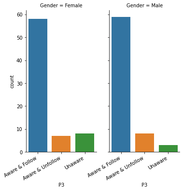

```python
chart=sns.catplot(x='P3', col='Gender', kind='count', data=SAIS, height=5, aspect=0.5,
                   order=SAIS['P3'].value_counts().index)
chart.set_xticklabels(rotation=30, horizontalalignment='right')
```

# P4 : Employee is not allowd to share any confidintial document even if he/she quit the job without permission.

```python
SAIS.groupby(['Job_Status']).P4.value_counts()
```

```
Job_Status  P4
Employee    Aware & Follow      56
            Aware & Unfollow     4
            Unaware              1
Other       Aware & Follow      48
            Unaware              3
Student     Aware & Follow      23
            Aware & Unfollow     7
            Unaware              1
Name: P4, dtype: int64
```

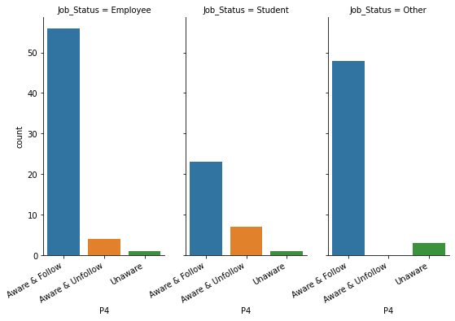

```python
chart=sns.catplot(x='P4', col='Job_Status', kind='count', data=SAIS, height=5, aspect=0.5,
                   order=SAIS['P4'].value_counts().index)
chart.set_xticklabels(rotation=30, horizontalalignment='right')
```

```python
SAIS.groupby(['Age']).P4.value_counts()
```

```
Age      P4
18 - 25  Aware & Follow      25
         Aware & Unfollow     5
         Unaware              2
26 - 35  Aware & Follow      39
         Aware & Unfollow     3
         Unaware              1
36 - 45  Aware & Follow      21
         Aware & Unfollow     2
46 - 60  Aware & Follow      42
         Unaware              2
         Aware & Unfollow     1
Name: P4, dtype: int64
```

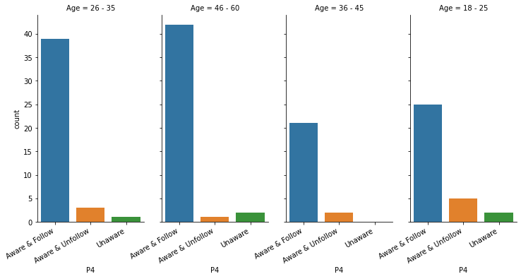

```python
chart=sns.catplot(x='P4', col='Age', kind='count', data=SAIS, height=5, aspect=0.5,
                   order=SAIS['P4'].value_counts().index)
chart.set_xticklabels(rotation=30, horizontalalignment='right')
```

```python
SAIS.groupby(['Gender']).P4.value_counts()
```

```
Gender  P4
Female  Aware & Follow      67
        Aware & Unfollow     3
        Unaware              3
Male    Aware & Follow      60
        Aware & Unfollow     8
        Unaware              2
Name: P4, dtype: int64
```

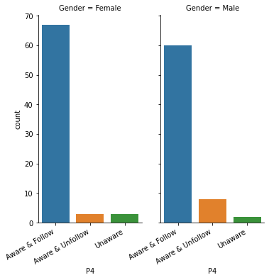

```python
chart=sns.catplot(x='P4', col='Gender', kind='count', data=SAIS, height=5, aspect=0.5,
                   order=SAIS['P4'].value_counts().index)
chart.set_xticklabels(rotation=30, horizontalalignment='right')
```

# P5 : Employee should not keep or print any papers outside the workplace unless follow the National Center for Archive.

```python
SAIS.groupby(['Job_Status']).P5.value_counts()
```

```
Job_Status  P5
Employee    Aware & Follow      57
            Aware & Unfollow     4
Other       Aware & Follow      48
            Unaware              3
Student     Aware & Follow      25
            Aware & Unfollow     4
            Unaware              2
Name: P5, dtype: int64
```

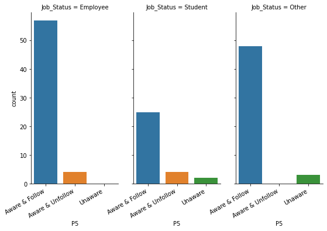

```python
chart=sns.catplot(x='P5', col='Job_Status', kind='count', data=SAIS, height=5, aspect=0.5,
                   order=SAIS['P5'].value_counts().index)
chart.set_xticklabels(rotation=30, horizontalalignment='right')
```

```python
SAIS.groupby(['Age']).P5.value_counts()
```

```
Age      P5
18 - 25  Aware & Follow      26
         Aware & Unfollow     4
         Unaware              2
26 - 35  Aware & Follow      37
         Aware & Unfollow     3
         Unaware              3
36 - 45  Aware & Follow      22
         Aware & Unfollow     1
46 - 60  Aware & Follow      45
Name: P5, dtype: int64
```

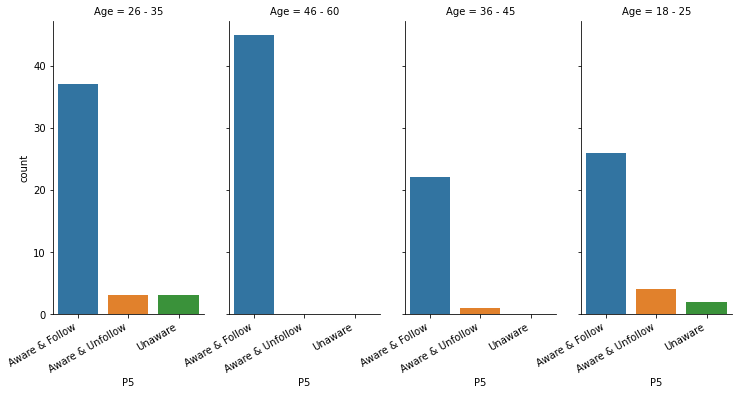

```python
chart=sns.catplot(x='P5', col='Age', kind='count', data=SAIS, height=5, aspect=0.5,
                   order=SAIS['P5'].value_counts().index)
chart.set_xticklabels(rotation=30, horizontalalignment='right')
```

```python
SAIS.groupby(['Gender']).P5.value_counts()
```

```
Gender  P5
Female  Aware & Follow      67
        Unaware              4
        Aware & Unfollow     2
Male    Aware & Follow      63
        Aware & Unfollow     6
        Unaware              1
Name: P5, dtype: int64
```

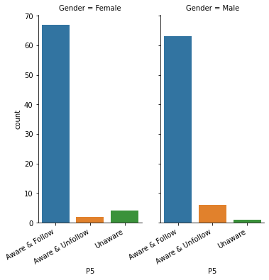

```python
chart=sns.catplot(x='P5', col='Gender', kind='count', data=SAIS, height=5, aspect=0.5,
                   order=SAIS['P5'].value_counts().index)
chart.set_xticklabels(rotation=30, horizontalalignment='right')
```

# P6 : The orgnizations must control and manage the system accessibility authorization by using (passwords- control critical and sisitive data access permission - review the access report periodically)

```python
SAIS.groupby(['Job_Status']).P6.value_counts()
```

```
Job_Status  P6
Employee    Aware & Follow      49
            Aware & Unfollow     6
            Unaware              6
Other       Aware & Follow      40
            Unaware              6
            Aware & Unfollow     5
Student     Aware & Follow      20
            Aware & Unfollow     6
            Unaware              5
Name: P6, dtype: int64
```

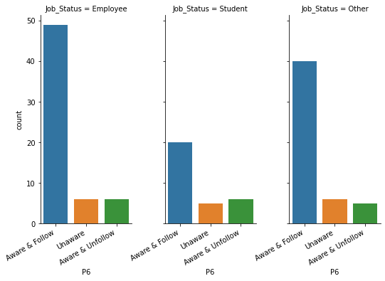

```python
chart=sns.catplot(x='P6', col='Job_Status', kind='count', data=SAIS, height=5, aspect=0.5,
                   order=SAIS['P6'].value_counts().index)
chart.set_xticklabels(rotation=30, horizontalalignment='right')
```

```python
SAIS.groupby(['Age']).P6.value_counts()
```

```
Age      P6
18 - 25  Aware & Follow      23
         Aware & Unfollow     5
         Unaware              4
26 - 35  Aware & Follow      28
         Unaware              9
         Aware & Unfollow     6
36 - 45  Aware & Follow      18
         Unaware              3
         Aware & Unfollow     2
46 - 60  Aware & Follow      40
         Aware & Unfollow     4
         Unaware              1
Name: P6, dtype: int64
```

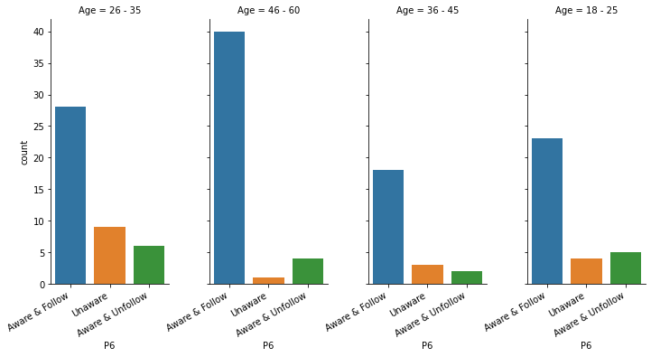

```python
chart=sns.catplot(x='P6', col='Age', kind='count', data=SAIS, height=5, aspect=0.5,
                   order=SAIS['P6'].value_counts().index)
chart.set_xticklabels(rotation=30, horizontalalignment='right')
```

```python
SAIS.groupby(['Gender']).P6.value_counts()
```

```
Gender  P6
Female  Aware & Follow      50
        Unaware             12
        Aware & Unfollow    11
Male    Aware & Follow      59
        Aware & Unfollow     6
        Unaware              5
Name: P6, dtype: int64
```

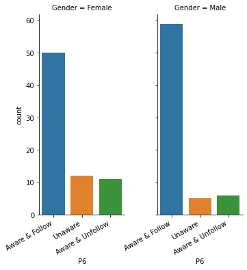

```python
chart=sns.catplot(x='P6', col='Gender', kind='count', data=SAIS, height=5, aspect=0.5,
                   order=SAIS['P6'].value_counts().index)
chart.set_xticklabels(rotation=30, horizontalalignment='right')
```

# P7 : Orgnizations must iniciate a proper cyber security enviroment aware ,and motivate thier employees to follow it.

```python
SAIS.groupby(['Job_Status']).P7.value_counts()
```

```
Job_Status  P7
Employee    Aware & Follow      47
            Aware & Unfollow    13
            Unaware              1
Other       Aware & Follow      40
            Unaware              6
            Aware & Unfollow     5
Student     Aware & Follow      18
            Aware & Unfollow     8
            Unaware              5
Name: P7, dtype: int64
```

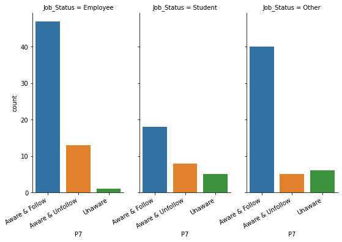

```python
chart=sns.catplot(x='P7', col='Job_Status', kind='count', data=SAIS, height=5, aspect=0.5,
                   order=SAIS['P7'].value_counts().index)
chart.set_xticklabels(rotation=30, horizontalalignment='right')
```

```python
SAIS.groupby(['Age']).P7.value_counts()
```

```
Age      P7
18 - 25  Aware & Follow      23
         Aware & Unfollow     8
         Unaware              1
26 - 35  Aware & Follow      32
         Unaware              7
         Aware & Unfollow     4
36 - 45  Aware & Follow      18
         Aware & Unfollow     5
46 - 60  Aware & Follow      32
         Aware & Unfollow     9
         Unaware              4
Name: P7, dtype: int64
```

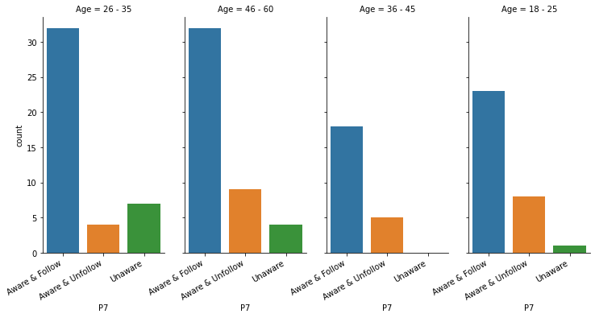

```python
chart=sns.catplot(x='P7', col='Age', kind='count', data=SAIS, height=5, aspect=0.5,
                   order=SAIS['P7'].value_counts().index)
chart.set_xticklabels(rotation=30, horizontalalignment='right')
```

```python
SAIS.groupby(['Gender']).P7.value_counts()
```

```
Gender  P7
Female  Aware & Follow      56
        Aware & Unfollow    10
        Unaware              7
Male    Aware & Follow      49
        Aware & Unfollow    16
        Unaware              5
Name: P7, dtype: int64
```

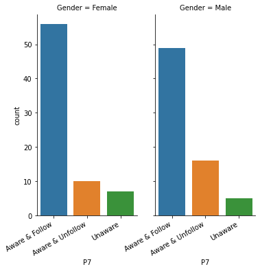

```python
chart=sns.catplot(x='P7', col='Gender', kind='count', data=SAIS, height=5, aspect=0.5,
                   order=SAIS['P7'].value_counts().index)
chart.set_xticklabels(rotation=30, horizontalalignment='right')
```

# P8 : Preacing others privacy or harshing them using mobile cameras are not allowed.

```python
SAIS.groupby(['Job_Status']).P8.value_counts()
```

```
Job_Status  P8
Employee    Aware & Follow      57
            Aware & Unfollow     4
Other       Aware & Follow      49
            Aware & Unfollow     2
Student     Aware & Follow      26
            Aware & Unfollow     5
Name: P8, dtype: int64
```

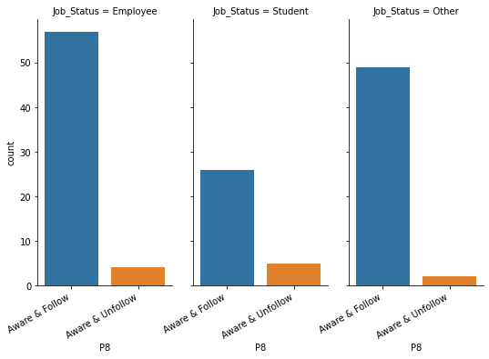

```python
chart=sns.catplot(x='P8', col='Job_Status', kind='count', data=SAIS, height=5, aspect=0.5,
                   order=SAIS['P8'].value_counts().index)
chart.set_xticklabels(rotation=30, horizontalalignment='right')
```

```python
SAIS.groupby(['Age']).P8.value_counts()
```

```
Age      P8
18 - 25  Aware & Follow      29
         Aware & Unfollow     3
26 - 35  Aware & Follow      38
         Aware & Unfollow     5
36 - 45  Aware & Follow      23
46 - 60  Aware & Follow      42
         Aware & Unfollow     3
Name: P8, dtype: int64
```

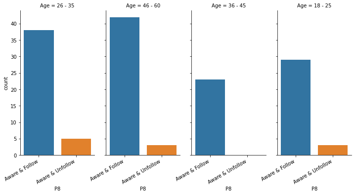

```python
chart=sns.catplot(x='P8', col='Age', kind='count', data=SAIS, height=5, aspect=0.5,
                   order=SAIS['P8'].value_counts().index)
chart.set_xticklabels(rotation=30, horizontalalignment='right')
```

```python
SAIS.groupby(['Gender']).P8.value_counts()
```

```
Gender  P8
Female  Aware & Follow      68
        Aware & Unfollow     5
Male    Aware & Follow      64
        Aware & Unfollow     6
Name: P8, dtype: int64
```

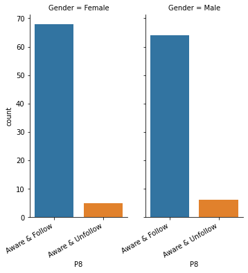

```python
chart=sns.catplot(x='P8', col='Gender', kind='count', data=SAIS, height=5, aspect=0.5,
                   order=SAIS['P8'].value_counts().index)
chart.set_xticklabels(rotation=30, horizontalalignment='right')
```